# Лабораторна робота 3

**Тема:** Геометричні перетворення зображення

**Мета:** знайомство з методами геометричних перетворень бібліотеки OpenCV у середовищі Anaconda із застосуванням Jupyter Notebook засобами мови програмування Python.

## Завдання для самостійної роботи

1. Завантажити Anaconda та активувати віртуальне середовище з ім’ям _OpenCV, створене у лабораторній роботі №1.

[figure not shown]

2. Створити Notebook-документ за допомогою Jupyter Notebook.

[figure not shown]

3. Імпортувати RGB-зображення Image з диску. Оцінити його розмір у пікселях N x M та об’єм пам’яті, який він займає на диску.

```
version cv2: 4.12.0
Розмір зображення (N x M): 149 x 199 пікселів
Кількість каналів: 3
Об'єм пам'яті на диску: 45775 байт (44.70 КБ)
```

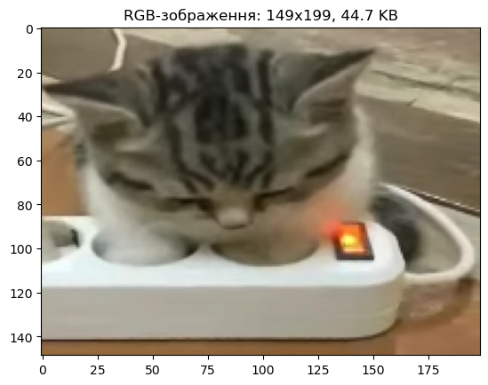

```python
import cv2 as cv
import numpy as np
import matplotlib.pyplot as plt
import os
print(f'version cv2: {cv.__version__}')
image_path = 'src/Color.png'
image = cv.imread(image_path)
if image is None:
    print(f"Не вдалося знайти файл! {image_path}")
else:
    N = image.shape[0]
    M = image.shape[1]
    C = image.shape[2]
    print(f"Розмір зображення (N x M): {N} x {M} пікселів")
    print(f"Кількість каналів: {C}")
    file_size_bytes = os.path.getsize(image_path)
    file_size_kb = file_size_bytes / 1024
    print(f"Об'єм пам'яті на диску: {file_size_bytes} байт ({file_size_kb:.2f} КБ)")
    image_rgb = cv.cvtColor(image, cv.COLOR_BGR2RGB)
    plt.imshow(image_rgb)
    plt.title(f"RGB-зображення: {N}x{M}, {file_size_kb:.1f} KB")
    plt.show()
```

4. Імпортувати RGB-зображення Image у напівтоновому форматі. Оцінити його розмір у пікселях та об’єм пам’яті, який він займає на диску. Порівняти результати з попередніми результатами. Пояснити результати.

```
ЗАВДАННЯ 3 (RGB)
Розмір (NxM):      149 x 199
Кількість каналів: 3
Об'єм на диску:    45775 байт
ЗАВДАННЯ 4 (Напівтонове)
Розмір (NxM):      149 x 199
Кількість каналів: 1
Об'єм на диску:    16099 байт
ПОРІВНЯННЯ
Розмір у пікселях:RGB: 149x199 | Gray: 149x199
Висновок: Розмір зображення не змінюється.
Об'єм на диску:RGB: 45775 байт| Gray: 16099 байт
Висновок: Файл RGB у 2.8 разів більший.Це тому, що RGB зберігає 3 канали на кожен піксель,а напівтонове — лише 1 канал.
```

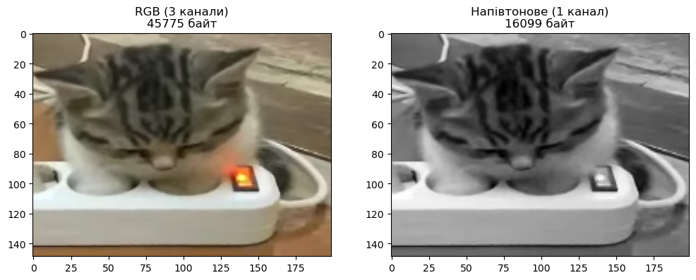

```python
import cv2 as cv
import os
import matplotlib.pyplot as plt
import numpy as np

image_path = 'src/Color.png'
image_bgr = cv.imread(image_path)
image_gray = cv.imread(image_path, cv.IMREAD_GRAYSCALE)

if image_bgr is None:
    print(f"Помилка: Не вдалося знайти файл {image_path}")
else:
    #ЗАВДАННЯ 3 (RGB)
    print(f"ЗАВДАННЯ 3 (RGB)")
    height_rgb, width_rgb, channels_rgb = image_bgr.shape
    file_size_rgb = os.path.getsize(image_path)
    print(f"Розмір (NxM):      {height_rgb} x {width_rgb}")
    print(f"Кількість каналів: {channels_rgb}")
    print(f"Об'єм на диску:    {file_size_rgb} байт")

    #ЗАВДАННЯ 4 (Напівтонове)
    print(f"ЗАВДАННЯ 4 (Напівтонове)")
    gray_path = 'src/Color_gray.png'
    cv.imwrite(gray_path, image_gray)
    height_gray, width_gray = image_gray.shape
    file_size_gray = os.path.getsize(gray_path)
    print(f"Розмір (NxM):      {height_gray} x {width_gray}")
    print(f"Кількість каналів: 1")
    print(f"Об'єм на диску:    {file_size_gray} байт")
    #ПОРІВНЯННЯ
    print(f"ПОРІВНЯННЯ")
    print(f"Розмір у пікселях:RGB: {height_rgb}x{width_rgb} | Gray: {height_gray}x{width_gray}")
    print(f"Висновок: Розмір зображення не змінюється.")
    print(f"Об'єм на диску:RGB: {file_size_rgb} байт| Gray: {file_size_gray} байт")
    ratio = file_size_rgb / file_size_gray
    print(f"Висновок: Файл RGB у {ratio:.1f} разів більший.Це тому, що RGB зберігає 3 канали на кожен піксель,а напівтонове — лише 1 канал.")
    plt.figure(figsize=(12, 6))

    plt.subplot(1, 2, 1)
    plt.imshow(cv.cvtColor(image_bgr, cv.COLOR_BGR2RGB))
    plt.title(f'RGB (3 канали)\n{file_size_rgb} байт')
    plt.subplot(1, 2, 2)
    plt.imshow(image_gray, cmap='gray')
    plt.title(f'Напівтонове (1 канал)\n{file_size_gray} байт')
    plt.show()
```

5. Зменшити початкове RGB-зображення Image у n разів, візуалізувати його, перевіривши результат масштабування, та експортувати його на диск. Чи змінився об’єм пам’яті, який він займає на диску? Обгрунтувати отриманий результат.

```
Результати:
Оригінал (N x M): 149 x 199
Об'єм (оригінал): 45775 байт (44.7 KB)

Зображення зменшено у 2 рази.
Новий розмір:74 x 99

Збережено як:src/Color_resized.png
Новий об'єм:12497 байт (12.2 KB)

Висновок
Так, об'єм пам'яті зменшився на 33278 байт (у 3.7 разів).
Обґрунтування: Кількість пікселів зменшилась в 4 рази для n=2.
Менше пікселів = менше даних для зберігання, тому файл став меншим.
```

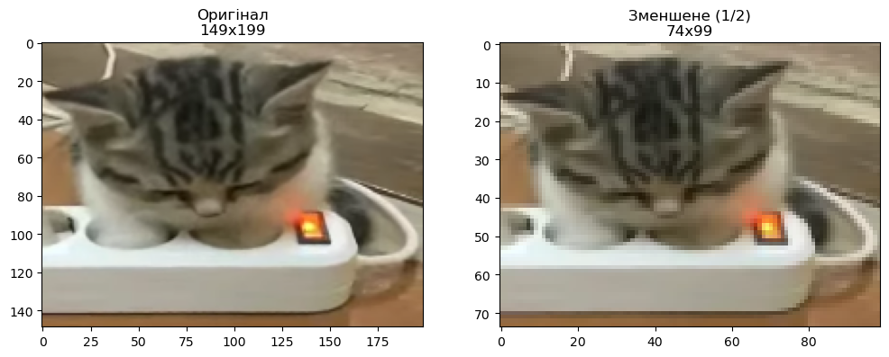

```python
import cv2 as cv
import os
import matplotlib.pyplot as plt
import math

image_path = 'src/Color.png'
n = 2
image_rgb = cv.imread(image_path)

if image_rgb is None:
    print(f"Не вдалося знайти файл! {image_path}")
else:
    height_N, width_M, _ = image_rgb.shape
    file_size_original = os.path.getsize(image_path)

    print(f"Результати:")
    print(f"Оригінал (N x M): {height_N} x {width_M}")
    print(f"Об'єм (оригінал): {file_size_original} байт ({file_size_original/1024:.1f} KB)\n")

    new_width = math.floor(width_M / n)
    new_height = math.floor(height_N / n)
    new_dim = (new_width, new_height)
    image_resized = cv.resize(image_rgb, new_dim, interpolation=cv.INTER_AREA)

    print(f"Зображення зменшено у {n} рази.")
    print(f"Новий розмір:{new_height} x {new_width}\n")

    # 4. Експорт на диск
    resized_path = 'src/Color_resized.png'
    cv.imwrite(resized_path, image_resized, [cv.IMWRITE_PNG_COMPRESSION, 9])
    file_size_resized = os.path.getsize(resized_path)
    print(f"Збережено як:{resized_path}")
    print(f"Новий об'єм:{file_size_resized} байт ({file_size_resized/1024:.1f} KB)\n")
    print(f"Висновок")
    if file_size_resized < file_size_original:
        diff = file_size_original - file_size_resized
        ratio = file_size_original / file_size_resized
        print(f"Так, об'єм пам'яті зменшився на {diff} байт (у {ratio:.1f} разів).")
        print("Обґрунтування: Кількість пікселів зменшилась в 4 рази для n=2.")
        print("Менше пікселів = менше даних для зберігання, тому файл став меншим.")
    else:
        print("Ні, об'єм пам'яті не зменшився або навіть збільшився.")

    # 6. Візуалізація
    plt.figure(figsize=(12, 6))

    # Оригінал
    plt.subplot(1, 2, 1)
    plt.imshow(cv.cvtColor(image_rgb, cv.COLOR_BGR2RGB))
    plt.title(f'Оригінал\n{height_N}x{width_M}')

    # Зменшене
    plt.subplot(1, 2, 2)
    plt.imshow(cv.cvtColor(image_resized, cv.COLOR_BGR2RGB))
    plt.title(f'Зменшене (1/{n})\n{new_height}x{new_width}')

    plt.show()
```

6. Написати функцію, яка буде виконувати пропорційне зменшення початкового зображення розміром N x M пікселей відповідно до вимоги, щоби зменешене зображення мало ширину K пікселей.

```
Результати Завдання 6
ширина K: 100 пікселів
Оригінал (h x w): 149 x 199
Результат (h x w): 74 x 100
```

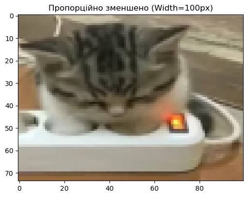

```
Файл збережено як src/Color_width.png
```

```python
import cv2 as cv
import matplotlib.pyplot as plt

def resize_proportional(image, target_width):
    (h, w) = image.shape[:2]
    ratio = target_width / float(w)
    target_height = int(h * ratio)
    new_dimensions = (target_width, target_height)
    resized_img = cv.resize(image, new_dimensions, interpolation=cv.INTER_AREA)
    return resized_img

image_path = 'src/Color.png'
K = 100

image_bgr = cv.imread(image_path)

if image_bgr is None:
    print(f"Помилка: Не вдалося знайти файл {image_path}")
else:
    image_resized_k = resize_proportional(image_bgr, K)

    print(f"Результати Завдання 6")
    print(f"ширина K: {K} пікселів")
    print(f"Оригінал (h x w): {image_bgr.shape[0]} x {image_bgr.shape[1]}")
    print(f"Результат (h x w): {image_resized_k.shape[0]} x {image_resized_k.shape[1]}")

    plt.figure(figsize=(6, 6))
    plt.imshow(cv.cvtColor(image_resized_k, cv.COLOR_BGR2RGB))
    plt.title(f'Пропорційно зменшено (Width={K}px)')
    plt.show()
    cv.imwrite(f'src/Color_width.png', image_resized_k)
    print(f"Файл збережено як src/Color_width.png")
```

7. Зробити фото розвороту власної залікової книжки з перспективним викривленням на фоні письмового столу. Вирізати зону із заліковкою та виконати афінні та перспективні перетворення за трьома точками точками і візуалізовані. В кожному випадку результати мають бути записані на диск.

```
Розмір зображення: 1280x822
Виконуємо афінне перетворення
Виконуємо перспективне перетворення
```

[figure not shown]

```
Результати збережено в папку src/
```

```python
import cv2 as cv
import numpy as np
import matplotlib.pyplot as plt

image_path = 'src/Zalik.png'
image = cv.imread(image_path)

if image is None:
    print(f"Помилка: Не знайдено файл {image_path}")
else:
    rows, cols, ch = image.shape
    print(f"Розмір зображення: {cols}x{rows}")

    print("Виконуємо афінне перетворення")

    pts_input_affine = np.float32([
        [415, 340],
        [573, 342],
        [410, 540]
    ])

    pts_output_affine = np.float32([
         [150, 220],
        [450, 210],
        [140, 600]
    ])

    M_affine = cv.getAffineTransform(pts_input_affine, pts_output_affine)
    img_affine = cv.warpAffine(image, M_affine, (cols, rows))

    cv.imwrite('src/Zalik_affine.jpg', img_affine)

    print("Виконуємо перспективне перетворення")

    pts_input_persp = np.float32([
       [330, 210],
        [520, 215],
        [330, 460],
        [520, 465]
    ])

    width_new, height_new = 300, 400

    pts_output_persp = np.float32([
        [0, 0],
        [width_new, 0],
        [0, height_new],
        [width_new, height_new]
    ])

    M_persp = cv.getPerspectiveTransform(pts_input_persp, pts_output_persp)
    img_perspective = cv.warpPerspective(image, M_persp, (width_new, height_new))

    cv.imwrite('src/Zalik_perspective.jpg', img_perspective)

    plt.figure(figsize=(12, 6))

    plt.subplot(1, 3, 1)
    plt.imshow(cv.cvtColor(image, cv.COLOR_BGR2RGB))
    plt.title("Оригінал")
    plt.grid(True)

    plt.subplot(1, 3, 2)
    plt.imshow(cv.cvtColor(img_affine, cv.COLOR_BGR2RGB))
    plt.title("Афінне")

    plt.subplot(1, 3, 3)
    plt.imshow(cv.cvtColor(img_perspective, cv.COLOR_BGR2RGB))
    plt.title("Перспективне")

    plt.show()
    print("Результати збережено в папку src/")
```

# **Контрольні запитання**

1. У чому полягає сенс афінних перетворень?

Сенс афінних перетворень полягає у зміні геометричної форми зображення при збереженні ключової властивості — паралельності прямих.Це означає, що якщо дві лінії були паралельними на вихідному зображенні, вони залишаться паралельними і після афінного перетворення наприклад, квадрат може перетворитися на паралелограм, але не на трапецію.

2. Чи є операції трансляції, масштабування і повороту афінними? Відповідь обґрунтувати.

Так, Афінне перетворення визначається як лінійне перетворення координат плюс вектор зсуву.

Трансляція (зсув): Просто додає вектор до координат точок. Паралельність ліній зберігається.

Масштабування: Множить координати на коефіцієнт. Паралельність зберігається.

Поворот: Обертає всі точки навколо центру на фіксований кут. Паралельність ліній зберігається. Оскільки у всіх цих випадках паралельні лінії залишаються паралельними, ці операції належать до класу афінних.

3. Чи є перспективні перетворення частинним випадком афінних перетворень? Відповідь обґрунтувати.

Ні,афінні є дуже специфічним, спрощеним випадком проєктивних/перспективних перетворень.

Тому що головна відмінність — це збереження паралельності.

Афінні перетворення завжди зберігають паралельність прямих.

Перспективні перетворення не зберігають паралельність. На перспективному зображенні паралельні в реальності лінії візуально сходяться в одній точці на горизонті.

Тому перспективне перетворення є більш загальним і складним класом, який може перетворити прямокутник на довільний чотирикутник, що неможливо для афінних перетворень.